### What is this App used for?

This App allows you to perform a liner regression, generate relative statistics and output graphics using your own datasets. Anyone who have interest in statistics and the need to perform either simple or multiple liner regression are welcome!

### What can this App do for me?

- **Name**: This blank allows you to write down your name.
- **Upload csv data file**: This function allows you to upload an external csv file which should identify the the first row as variable names that follows the naming conventions in R (e.g.: all letters are lower case and only separated by period or underscore).
- **Load test dataset**: This button allows you to load our default dataset as an example to help you walk through the App. Further exhibition and interpretation of how our App works for liner regression will be provided. Then, it is easier for you to understand the statistics and graphics when using your own data.
- **Explanatory Variables (Numeric)**: This selection box lets you select one or multiple numeric explanatory variable(s).
- **Explanatory Variables (Categorical)**: This selection box lets you select one or multiple categorical/dichotomous explanatory variable(s).
- **Outcome variable**: This selection box lets you select only one outcome variable of your interest. The outcome variable should be numerical to satisfy linear model assumption.
- **Name of dataset**: This text input box lets you type the name of the dataset. If you load the test dataset, the default name will be birthwt.
- **Author name**: This text input box lets you type your name.
- **Document format**: This radio buttons lets you choose the format of your report. You can choose pdf, html of word.
- **Download Button**: This botton allows you to download your regression report.
- **Interpretation**: This text input box under every tabset allows you to write the interpretation based on the output.

### What statistics and graphics can I obtain using this App?

- **Scatterplot**: it shows how one variable is affected by another for two variables. When multiple variables are chosen, it becomes a scatterplot matrix which could determine liner relationship among those variables. Only numerical variables are shown in the App.
- **Boxplots**: it is a visualization of summary statistics (minimum, first quartile, median, third quartile and maximum) for categorical data. The plot won’t show if your model only contains numerical variables.
- **Summary statistics**: it gives an R output for the model you build. Outputs include estimates, standard error, p value, etc. for all the variables and R squared for the model. This provides you a numerical summary of your model.
- **Diagnostic plots**: There are four plots of diagnostics to check the assumption of linear regression. Further explanation will be given in the example.
- **Added variable plots**: it is a widely used index mainly in multiple linear regression to check how much a certain added variable contribute to the model. Further explanation will be given in the example.
- **Marginal model plots**: it is a widely used index mainly in multiple linear regression to visualize how close the created model fits your data. Further explanation will be given in the example.

### An example using the default low infant birth weight data.

Here is an example to help you walk through all the functions our App has. All the interpration will be useful in explaining your own data.

Data description: The default data “birthwt” can be used to identify risk factors associated with giving birth to a low birth weight baby (weighing less than 2500 grams). Data were collected on 189 women, 59 of which had low birth weight babies and 130 of which had normal birth weight babies. The variables identified below have been shown to be associated with low birth weight in the obstetrical literature. The goal of our current example was to ascertain if these variables were important in the population being served by the medical center where the data were collected. This data is from Hosmer et al. , 2013.

- Low: indicator of birth weight less than 2.5 kg.
- Age: mother’s age in years.
- Lwt: mother’s weight in pounds at last menstrual period.
- Race: mother’s race (1 = white, 2 = black, 3 = other).
- Smoke: smoking status during pregnancy.
- Ptl: number of previous premature labours.
- Ht: history of hypertension.
- Ui: presence of uterine irritability.
- Ftv: number of physician visits during the first trimester.
- Bwt: birth weight in grams.

In this model building mother’s age, mother’s weight in pounds at last menstrual period, mother’s smoke status (categorical) are assumed important factors predicting infants’ birth weight thus are included.

First, explore the linear relationship between infants’ birth weight and numerical covariates by creating a scatterplot matrix. There seem to be positive linear relationship among the three varibales; however, it is hard to tell how much they associate with each other.

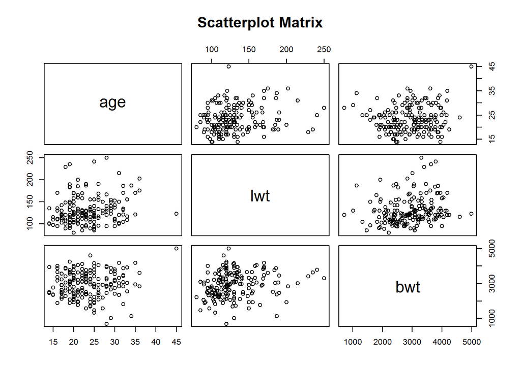

Boxplot is mainly used for categorical data. In this plot, we can crudely read that infants of non-smoking mothers are lightly heavier than that of smoking mothers, and non-smoking mothers seem to have more extreme large values thus making them have bigger standard deviation of birth weight. We also notice there is an extreme value in smoking mother, but it is hard to tell whether the extreme value would be a outlier only from this plot.

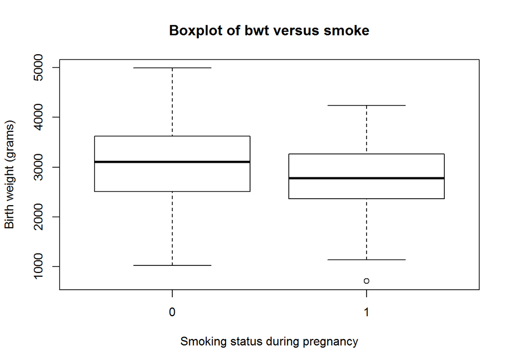

Summary statistics demonstrates this model is a significant model predicting low birth weight at a 0.05 alpha level (p=0.0036). Mother’s weight and smoking status are associate with infants’ low birth weight while mother’s age is insignificant with a p value greater than 0.05. The R-squared being small (0.07) reveals the model is not a good fit.

```
##
## Call:
## lm(formula = bwt ~ age + lwt + as.factor(smoke), data = birthwt)
##
## Residuals:
##      Min       1Q   Median       3Q      Max
## -2070.97  -431.56    12.95   521.70  1811.67
##
## Coefficients:
##                   Estimate Std. Error t value Pr(>|t|)
## (Intercept)       2362.495    300.683   7.857 3.12e-13 ***
## age                  7.154      9.925   0.721   0.4719
## lwt                  4.016      1.720   2.335   0.0206 *
## as.factor(smoke)1 -269.257    105.801  -2.545   0.0117 *
## ---
## Signif. codes:  0 '***' 0.001 '**' 0.01 '*' 0.05 '.' 0.1 ' ' 1
##
## Residual standard error: 708.8 on 185 degrees of freedom
## Multiple R-squared:  0.07039,    Adjusted R-squared:  0.05531
## F-statistic: 4.669 on 3 and 185 DF,  p-value: 0.003606
```

Diagnostic plots are used to check the assumption of linear regression. For the residuals vs. fitted plot, the residual line is around 0, suggesting linearity satisfied and the variance of the error terms are equal. For the Q-Q plot, it shows that the residuals are approximately normally distributed, but not heavly tailed. Several data points with large residuals are highlighted with a number aside the residual line. These data points may be outliers in this model.The location-scale plot is useful for checking the assumption of homoscedasticity. The standard deviations of the error terms should be constant and do not depend on the x-value, which means that there are no patterns in the residuals thus standard residuals do not have relationship with the fitted value. From the plot we can see the assumption of homoscedasticity is satisfied. The residuals vs leverage plot is used to identify influencial observations. Cook’s distance is a standard estimate to assess the influence of a data point when performing linear regression. We could see the observations are well behaved. The extreme value found in the boxplot is not an outlier.

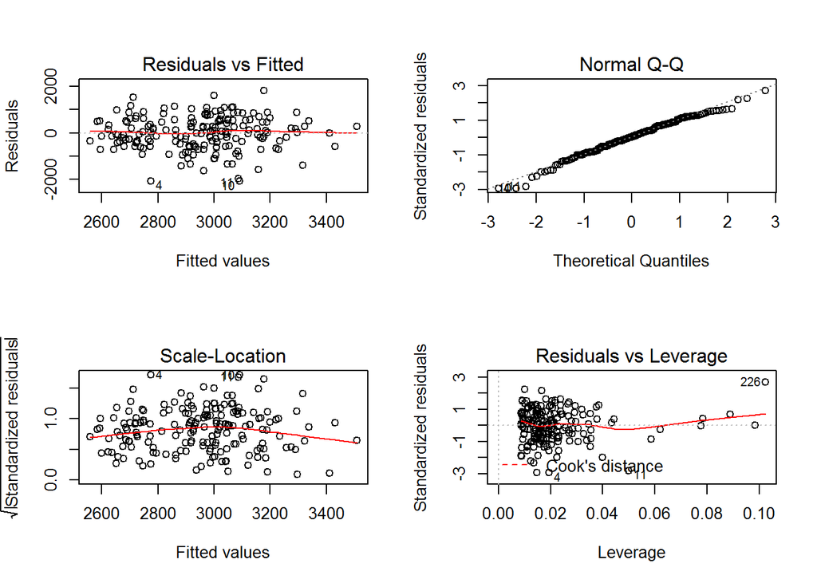

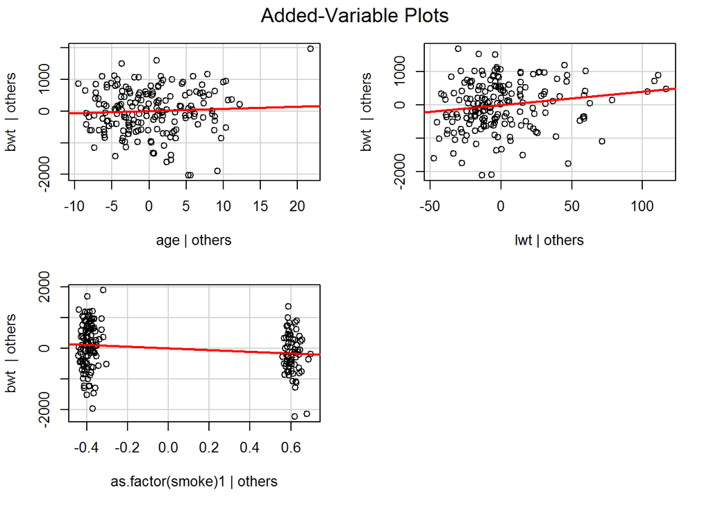

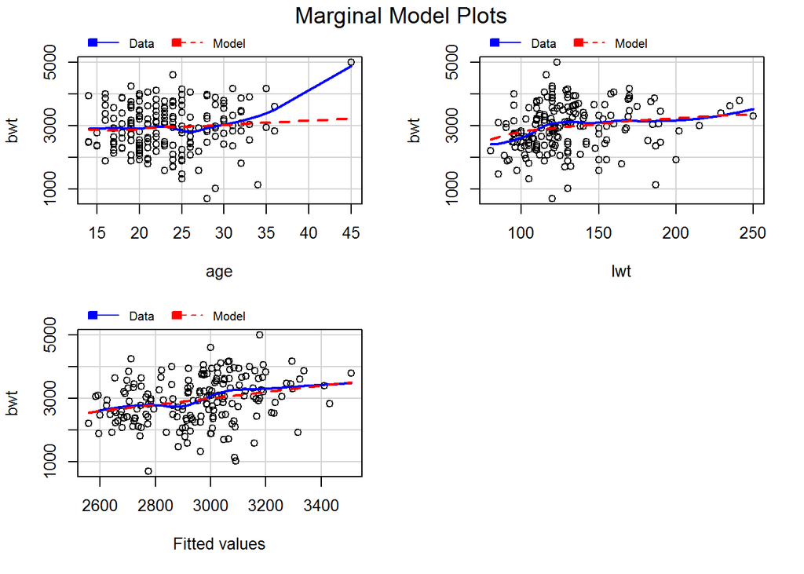